# San Francisco Crime Insights

Steven Oshry

Sunday, March 21, 2016

## Introduction

This is an analysis of crime data from the city of San Francisco between June 1, 2014 and August 31, 2014. There were many different categories of crimes given, I decided to restrict this analysis to violent crimes only. The categories for violent crimes are assault and robbery. Bar charts are shown looking at violent crime by Day of week, Time of day, and Time of Day within Day of week. Finally a heat map is shown superimposed over a map of San Francisco to demonstrate the power of visula presentation of data. The code (R markdown) to create this analysis is in the Github repository https://github.com/StevenOshry/Coursera_visualization_SF_crime-data

## Day of Week Chart

The chart below shows the violent crimes by day of week. There does not appear to be a strong realtionship.

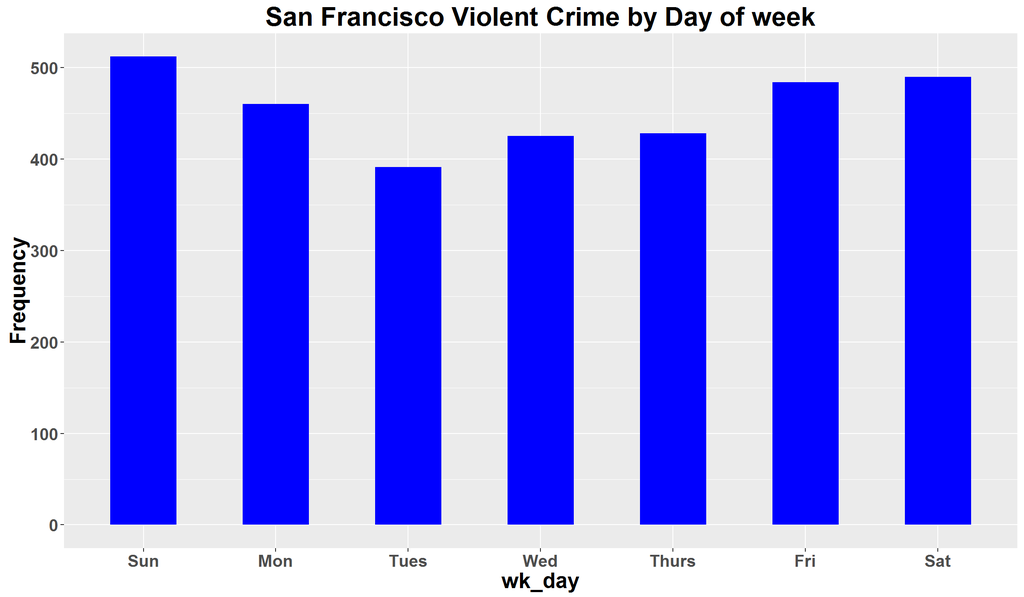

## Time of Day Chart

The chart below shows the violent crimes by Time of Day. There also does not appear to be a strong realtionship.

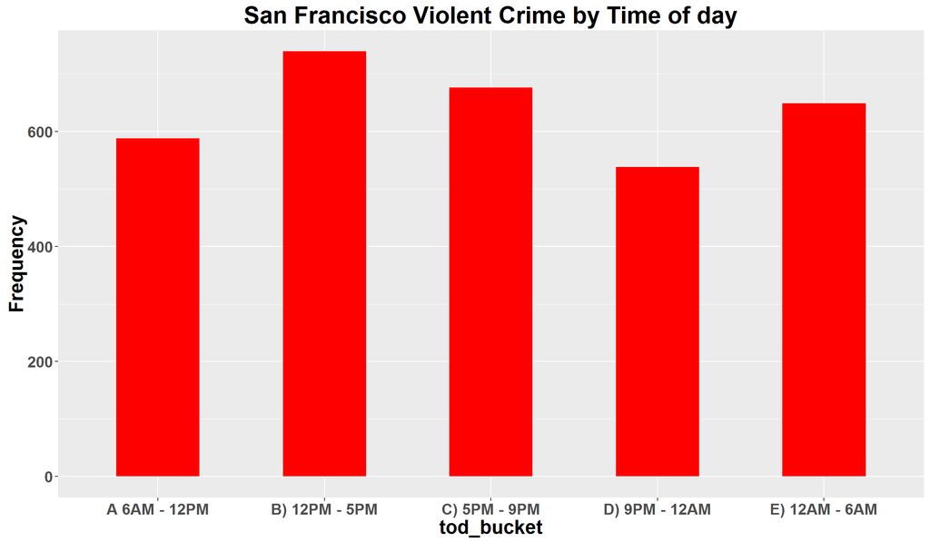

## Time of Day within Day of Week Chart

The chart below shows the violent crimes by Time of Day within Day of Week. Here we can see that violent crimes are more frequent Friday and Saturday evenings and very early Sunday mroning(12 Am - 6 AM )

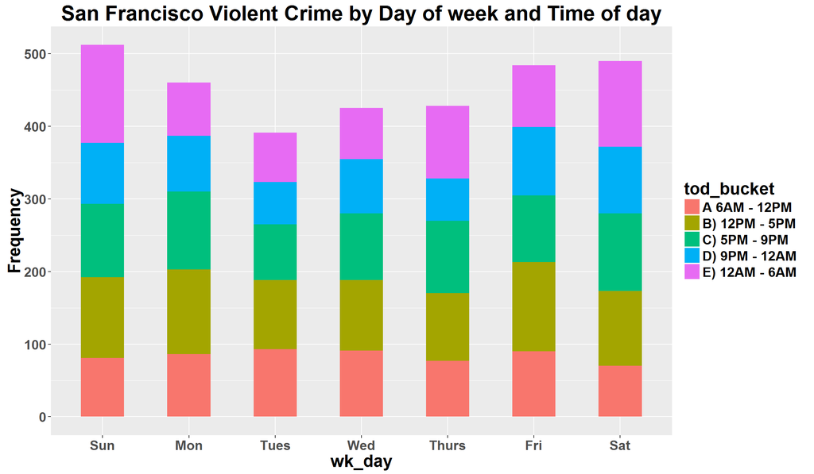

## Heat Map Results

The chart below is a violent crime map of San Fran. This visualization clearly shows that most of the violent crime is concentrated in 1 area

[figure not shown]